# Lecture 5 Stationarity

## Stationarity

A time series $Z_t$ is defined to be  
(weakly or covariance) stationary if: $\newcommand{\var}{\textrm{var}}$ $\newcommand{\cov}{\textrm{cov}}$

1. $E(Z_t)$ is constant across all $t$.
2. $\var(Z_t)$ is finite and constant across all $t$.
3. For each $j=1,2,\ldots,$  
   $\cov(Z_t,Z_{t-j})$ is constant across all $t$.

Various behaviours of time series, models and forecasts can depend on this.

$${\large{\textbf{Are prediction errors stationary?}}}$$

## Are prediction errors stationary?

$$U_t = Y_t - E(Y_t | {\mathscr{Y}}_{t-1})$$

Recall $E(U_t | {\mathscr{Y}}_{t-1})=0$

## Are prediction errors stationary?

$$U_t = Y_t - E(Y_t | {\mathscr{Y}}_{t-1})$$

Recall $E(U_t | {\mathscr{Y}}_{t-1})=0$, and this implies

1. $E(U_t)=0$ across all $t$. ${\phantom{\Large\checkmark}}$

## Are prediction errors stationary?

$$U_t = Y_t - E(Y_t | {\mathscr{Y}}_{t-1})$$

Recall $E(U_t | {\mathscr{Y}}_{t-1})=0$, and this implies

1. $E(U_t)=0$ across all $t$. ${\color{lime}{\Large\checkmark}}$

## Are prediction errors stationary?

$$U_t = Y_t - E(Y_t | {\mathscr{Y}}_{t-1})$$

Recall $E(U_t | {\mathscr{Y}}_{t-1})=0$, and this implies

1. $E(U_t)=0$ across all $t$. ${\color{lime}{\Large\checkmark}}$
3. For each $j=1,2,\ldots,$  
   $\cov(U_t,U_{t-j})=0$ across all $t$. ${\phantom{\Large\checkmark}}$

## Are prediction errors stationary?

$$U_t = Y_t - E(Y_t | {\mathscr{Y}}_{t-1})$$

Recall $E(U_t | {\mathscr{Y}}_{t-1})=0$, and this implies

1. $E(U_t)=0$ across all $t$. ${\color{lime}{\Large\checkmark}}$
3. For each $j=1,2,\ldots,$  
   $\cov(U_t,U_{t-j})=0$ across all $t$. ${\color{lime}{\Large\checkmark}}$

## Are prediction errors stationary?

$$U_t = Y_t - E(Y_t | {\mathscr{Y}}_{t-1})$$

Recall $E(U_t | {\mathscr{Y}}_{t-1})=0$, and this implies

1. $E(U_t)=0$ across all $t$. ${\color{lime}{\Large\checkmark}}$
2. $\var(U_t) = \: ?$
3. For each $j=1,2,\ldots,$  
   $\cov(U_t,U_{t-j})=0$ across all $t$. ${\color{lime}{\Large\checkmark}}$

## Are prediction errors stationary?

$$U_t = Y_t - E(Y_t | {\mathscr{Y}}_{t-1})$$

Recall $E(U_t | {\mathscr{Y}}_{t-1})=0$, and this implies

1. $E(U_t)=0$ across all $t$. ${\color{lime}{\Large\checkmark}}$
2. $U_t$ might be heteroskedastic.
3. For each $j=1,2,\ldots,$  
   $\cov(U_t,U_{t-j})=0$ across all $t$. ${\color{lime}{\Large\checkmark}}$

## Are prediction errors stationary?

$$U_t = Y_t - E(Y_t | {\mathscr{Y}}_{t-1})$$

Recall $E(U_t | {\mathscr{Y}}_{t-1})=0$, and this implies

1. $E(U_t)=0$ across all $t$. ${\color{lime}{\Large\checkmark}}$
2. Can assume $\var(U_t) = \sigma^2$ across all $t$.
3. For each $j=1,2,\ldots,$  
   $\cov(U_t,U_{t-j})=0$ across all $t$. ${\color{lime}{\Large\checkmark}}$

$${\large{\textbf{MA(1) Model}}}$$

## MA(1) Model

$$Y_t = U_t + \theta_1 U_{t-1}, \quad
\var(U_t) = \sigma^2$$
where $U_t$ is a *stationary* prediction error.

## MA(1) Model

$$Y_t = U_t + \theta_1 U_{t-1}, \quad
\var(U_t) = \sigma^2$$
where $U_t$ is a *stationary* prediction error.

$$\begin{align}
1. \quad E(Y_t) &= {\color{magenta}{E(U_t)}} +
\theta_1 \ {\color{magenta}{E(U_{t-1})}} \\
&= \quad {\color{magenta}{0}} \quad + \theta_1 \quad {\color{magenta}{0}}
\qquad\qquad\qquad\qquad\qquad\qquad\qquad\qquad\qquad
\end{align}$$

## MA(1) Model

$$Y_t = U_t + \theta_1 U_{t-1}, \quad
\var(U_t) = \sigma^2$$
where $U_t$ is a *stationary* prediction error.

$$\begin{align}
1. \quad E(Y_t) &= \ {\color{magenta}{0}}
\quad {\color{lime}{\checkmark}}
\qquad\qquad\qquad\qquad\qquad\qquad\qquad\qquad
\end{align}$$

## MA(1) Model

$$Y_t = U_t + \theta_1 U_{t-1}, \quad
\var(U_t) = \sigma^2$$
where $U_t$ is a *stationary* prediction error.

$$\begin{align}
1.& \quad E(Y_t) = \ 0
\quad {\color{lime}{\checkmark}}
\qquad\qquad\qquad\qquad\qquad\qquad\qquad\qquad \\
2.& \quad \var(Y_t) = \var(U_t) + 2\theta_1\cov(U_t,U_{t-1})
+\theta_1^2 \ \var(U_{t-1})
\end{align}$$

## MA(1) Model

$$Y_t = U_t + \theta_1 U_{t-1}, \quad
\var(U_t) = \sigma^2$$
where $U_t$ is a *stationary* prediction error.

$$\begin{align}
1.& \quad E(Y_t) = \ 0
\quad {\color{lime}{\checkmark}}
\qquad\qquad\qquad\qquad\qquad\qquad\qquad\qquad \\
2.& \quad \var(Y_t) = {\color{orange}{\var(U_t)}}
+ 2\theta_1 {\color{magenta}{\cov(U_t,U_{t-1})}}
+ \theta_1^2\ {\color{orange}{\var(U_{t-1})}} \\
& \quad \phantom{\var(Y_t)} = \quad {\color{orange}{\sigma^2}} \quad\, + 2\theta_1 \qquad {\color{magenta}{0}}
\qquad\quad
+ \theta_1^2\ \quad {\color{orange}{\sigma^2}}
\end{align}$$

## MA(1) Model

$$Y_t = U_t + \theta_1 U_{t-1}, \quad
\var(U_t) = \sigma^2$$
where $U_t$ is a *stationary* prediction error.

$$\begin{align}
1.& \quad E(Y_t) = \ 0
\quad {\color{lime}{\checkmark}}
\qquad\qquad\qquad\qquad\qquad\qquad\qquad\qquad \\
2.& \quad \var(Y_t) = \sigma^2(1+\theta_1^2) \text{ for every } t
\quad {\color{lime}{\checkmark}}
\end{align}$$

## MA(1) Model

$$Y_t = U_t + \theta_1 U_{t-1}, \quad
\var(U_t) = \sigma^2$$
where $U_t$ is a *stationary* prediction error.

$$\begin{align}
1.& \quad E(Y_t) = \ 0
\quad {\color{lime}{\checkmark}}
\qquad\qquad\qquad\qquad\qquad\qquad\qquad\qquad \\
2.& \quad \var(Y_t) = \sigma^2(1+\theta_1^2) \text{ for every } t
\quad {\color{lime}{\checkmark}}
\\
3. & \quad \cov(Y_t,Y_{t-1}) = \sigma^2\theta_1 \qquad\qquad\qquad {\color{lime}{\checkmark}} \\
& \quad \cov(Y_t,Y_{t-j}) = \: 0 \quad(j=2,3,\ldots)
\:\:\: {\color{lime}{\checkmark}}
\end{align}$$

$${\large{\textbf{Linear Trend Model}}}$$

## Linear Trend Model

$$Y_t = \beta_0 + \beta_1 \text{Time}_t + U_t$$
where $U_t$ is a *stationary* prediction error.

## Linear Trend Model

$$Y_t = \beta_0 + \beta_1 \text{Time}_t + U_t$$
where $U_t$ is a *stationary* prediction error.

$$\begin{align}
1. &\quad E(Y_t) = \beta_0 + \beta_1
{\color{cyan}{\text{Time}_t}} + E(U_t)
\qquad\qquad\qquad\qquad\qquad\qquad \\
\\
& \qquad\qquad {\color{cyan}{(\text{Time}_t \text{ is deterministic})}}
\end{align}$$

## Linear Trend Model

$$Y_t = \beta_0 + \beta_1 \text{Time}_t + U_t$$
where $U_t$ is a *stationary* prediction error.

$$\begin{align}
1. &\quad E(Y_t) = \beta_0 + \beta_1
\text{Time}_t + \: {\color{magenta}{0}}
\qquad\qquad\qquad\qquad\qquad\qquad \\
\end{align}$$

## Linear Trend Model

$$Y_t = \beta_0 + \beta_1 \text{Time}_t + U_t$$
where $U_t$ is a *stationary* prediction error.

$$\begin{align}
1. &\quad {\color{cyan}{E(Y_t)}} = \beta_0 + \beta_1
{\color{orange}{\text{Time}_t}}
\qquad\qquad\qquad\qquad\qquad\qquad \\
\end{align}$$

Mean depends on time $\quad \Rightarrow\quad$ **not** stationary.

$${\large{\textbf{AR(1) Model}}}$$

## AR(1) Model

$$Y_t = \phi_1 Y_{t-1} + U_t$$
where $U_t$ is a *stationary* prediction error.

## AR(1) Model

$$Y_t = \phi_1 Y_{t-1} + U_t$$
where $U_t$ is a *stationary* prediction error.

$$\begin{align}
1. & \quad E(Y_t) = \phi_1 E(Y_{t-1}) + E(U_t)
\qquad\qquad\qquad\qquad\qquad\qquad \\
\end{align}$$

## AR(1) Model

$$Y_t = \phi_1 Y_{t-1} + U_t$$
where $U_t$ is a *stationary* prediction error.

$$\begin{align}
1. & \quad E(Y_t) = \phi_1 E(Y_{t-1}) + \:
{\color{magenta}{0}}
\qquad\qquad\qquad\qquad\qquad\qquad \\
\end{align}$$

## AR(1) Model

$$Y_t = \phi_1 Y_{t-1} + U_t$$
where $U_t$ is a *stationary* prediction error.

$$\begin{align}
1. & \quad E(Y_t) = \phi_1 E(Y_{t-1})
\qquad\qquad\qquad\qquad\qquad\qquad \\
\end{align}$$

Is it possible for $E(Y_t)=E(Y_{t-1})$?

(i.e. mean not changing from one time to the next?)

## AR(1) Model

$$Y_t = \phi_1 Y_{t-1} + U_t$$
where $U_t$ is a *stationary* prediction error.

$$\begin{align}
1. & \quad E(Y_t) = \phi_1 E(Y_{t-1})
\qquad\qquad\qquad\qquad\qquad\qquad \\
\end{align}$$
$E(Y_t)=E(Y_{t-1})$ requires $E(Y_t)=0$ for every $t$.

## AR(1) Model

$$Y_t = \phi_1 Y_{t-1} + U_t$$
where $U_t$ is a *stationary* prediction error.

$$\begin{align}
1. & \quad E(Y_t) = \phi_1 E(Y_{t-1})
\qquad\qquad\qquad\qquad\qquad\qquad \\
\end{align}$$

Formally, by induction:

- if we *assume* $E(Y_1) = 0$
- then $E(Y_t)=0$ for every $t$.

## AR(1) Model

$$Y_t = \phi_1 Y_{t-1} + U_t$$
where $U_t$ is a *stationary* prediction error.

$$\begin{align}
1. & \quad E(Y_t) = \phi_1 E(Y_{t-1})
\qquad\qquad\qquad\qquad\qquad\qquad \\
\end{align}$$

If we assume $E(Y_1) = \mu_1 \ne 0$ then

$\qquad\qquad\quad\:\: E(Y_2)= \phi_1 \mu_1$

$\qquad\qquad\quad\:\: E(Y_3)= \phi_1^2 \mu_1$

i.e. $E(Y_t)$ changes with $t$

## AR(1) Model

$$Y_t = \phi_1 Y_{t-1} + U_t$$
where $U_t$ is a *stationary* prediction error.

$$\begin{align}
1. & \quad E(Y_t) = 0 \text{ for every } t
\qquad\qquad\qquad\qquad\qquad\qquad\qquad\qquad\qquad \\
\end{align}$$

## AR(1) Model

$$Y_t = \phi_1 Y_{t-1} + U_t$$
where $U_t$ is a *stationary* prediction error.

$$\begin{align}
2. & \quad \var(Y_t) = \phi_1^2 \ \var(Y_{t-1}) + \var(U_t) \\
& \qquad\qquad\qquad + 2 \ \phi_1 \ \cov(Y_{t-1}, U_t)
\qquad\qquad\qquad\qquad\qquad\qquad\qquad\qquad\qquad \\
\end{align}$$

## AR(1) Model

$$Y_t = \phi_1 Y_{t-1} + U_t$$
where $U_t$ is a *stationary* prediction error.

$$\begin{align}
2. & \quad \var(Y_t) = \phi_1^2 \ \var(Y_{t-1}) + \var(U_t) \\
& \qquad\qquad\qquad + 2 \ \phi_1 \
{\color{cyan}{\cov(Y_{t-1}, U_t)}}
\qquad\qquad\qquad\qquad\qquad\qquad\qquad\qquad\qquad \\
\end{align}$$

$$\begin{align}
{\color{cyan}{\cov(Y_{t-1}, U_t)}}
&= E[ \ Y_{t-1} \ U_t \ ]
\quad \text{(since } E(U_t)=0) \qquad\qquad\qquad\qquad\qquad
\end{align}$$

## AR(1) Model

$$Y_t = \phi_1 Y_{t-1} + U_t$$
where $U_t$ is a *stationary* prediction error.

$$\begin{align}
2. & \quad \var(Y_t) = \phi_1^2 \ \var(Y_{t-1}) + \var(U_t) \\
& \qquad\qquad\qquad + 2 \ \phi_1 \
{\color{cyan}{\cov(Y_{t-1}, U_t)}}
\qquad\qquad\qquad\qquad\qquad\qquad\qquad\qquad\qquad \\
\end{align}$$

$$\begin{align}
{\color{cyan}{\cov(Y_{t-1}, U_t)}}
&= E[ \ Y_{t-1} \ U_t \ ]
\quad \text{(since } E(U_t)=0) \qquad\qquad\qquad\qquad\qquad \\
&= E[ \ E(Y_{t-1} \ U_t \ | {\mathscr{Y}}_{t-1} ) ] \quad \text{(LIE)} \\
\end{align}$$

## AR(1) Model

$$Y_t = \phi_1 Y_{t-1} + U_t$$
where $U_t$ is a *stationary* prediction error.

$$\begin{align}
2. & \quad \var(Y_t) = \phi_1^2 \ \var(Y_{t-1}) + \var(U_t) \\
& \qquad\qquad\qquad + 2 \ \phi_1 \
{\color{cyan}{\cov(Y_{t-1}, U_t)}}
\qquad\qquad\qquad\qquad\qquad\qquad\qquad\qquad\qquad \\
\end{align}$$

$$\begin{align}
{\color{cyan}{\cov(Y_{t-1}, U_t)}}
&= E[ \ Y_{t-1} \ U_t \ ]
\quad \text{(since } E(U_t)=0) \qquad\qquad\qquad\qquad\qquad \\
&= E[ \ E(Y_{t-1} \ U_t \ | {\mathscr{Y}}_{t-1} ) ] \quad \text{(LIE)} \\
&= E[ \ Y_{t-1} \ E( U_t \ | {\mathscr{Y}}_{t-1} ) ] \quad
(Y_{t-1} \in {\mathscr{Y}}_{t-1})
\end{align}$$

## AR(1) Model

$$Y_t = \phi_1 Y_{t-1} + U_t$$
where $U_t$ is a *stationary* prediction error.

$$\begin{align}
2. & \quad \var(Y_t) = \phi_1^2 \ \var(Y_{t-1}) + \var(U_t) \\
& \qquad\qquad\qquad + 2 \ \phi_1 \
{\color{cyan}{\cov(Y_{t-1}, U_t)}}
\qquad\qquad\qquad\qquad\qquad\qquad\qquad\qquad\qquad \\
\end{align}$$

$$\begin{align}
{\color{cyan}{\cov(Y_{t-1}, U_t)}}
&= E[ \ Y_{t-1} \ U_t \ ]
\quad \text{(since } E(U_t)=0) \qquad\qquad\qquad\qquad\qquad \\
&= E[ \ E(Y_{t-1} \ U_t \ | {\mathscr{Y}}_{t-1} ) ] \quad \text{(LIE)} \\
&= E[ \ Y_{t-1} \ {\color{magenta}{E( U_t \ | {\mathscr{Y}}_{t-1} )}} ] \quad
(Y_{t-1} \in {\mathscr{Y}}_{t-1}) \\
&= {\color{magenta}{0}}
\end{align}$$

## AR(1) Model

$$Y_t = \phi_1 Y_{t-1} + U_t$$
where $U_t$ is a *stationary* prediction error.

$$\begin{align}
2. & \quad \var(Y_t) = \phi_1^2 \ \var(Y_{t-1}) + \var(U_t)
\qquad\qquad\qquad\qquad\qquad\qquad\qquad\qquad\qquad \\
\end{align}$$

## AR(1) Model

$$Y_t = \phi_1 Y_{t-1} + U_t$$
where $U_t$ is a *stationary* prediction error.

$$\begin{align}
2. & \quad \var(Y_t) = \phi_1^2 \ \var(Y_{t-1}) + \: {\color{cyan}{\sigma^2}}
\qquad\qquad\qquad\qquad\qquad\qquad\qquad\qquad\qquad \\
\end{align}$$

## AR(1) Model

$$Y_t = \phi_1 Y_{t-1} + U_t$$
where $U_t$ is a *stationary* prediction error.

$$\begin{align}
2. & \quad \var(Y_t) = \phi_1^2 \ \var(Y_{t-1}) + \: {\color{cyan}{\sigma^2}}
\qquad\qquad\qquad\qquad\qquad\qquad\qquad\qquad\qquad \\
\end{align}$$

Is it possible for $\var(Y_t) = \var(Y_{t-1})$?

(i.e. var not changing from one time to the next?)

## AR(1) Model

$$Y_t = \phi_1 Y_{t-1} + U_t$$
where $U_t$ is a *stationary* prediction error.

$$\begin{align}
2. & \quad {\color{magenta}{\var(Y_t)}} =
\phi_1^2 \ {\color{magenta}{\var(Y_{t-1})}} + \: {\color{cyan}{\sigma^2}}
\qquad\qquad\qquad\qquad\qquad\qquad\qquad\qquad\qquad \\
\end{align}$$

Is it possible for ${\color{magenta}{\var(Y_t)}} = {\color{magenta}{\var(Y_{t-1})}}$?

## AR(1) Model

$$Y_t = \phi_1 Y_{t-1} + U_t$$
where $U_t$ is a *stationary* prediction error.

$$\begin{align}
2. & \quad {\color{magenta}{\var(Y_t)}} =
\phi_1^2 \ {\color{magenta}{\var(Y_{t})}} \:\:\:\:
+ \: {\color{cyan}{\sigma^2}}
\qquad\qquad\qquad\qquad\qquad\qquad\qquad\qquad\qquad \\
\end{align}$$

$$\Rightarrow\quad {\color{magenta}{\var(Y_t)}} =
\frac{\color{cyan}{\sigma^2}}{1-\phi_1^2}
\qquad\qquad\qquad\qquad\qquad\qquad\qquad\qquad$$

## AR(1) Model

$$Y_t = \phi_1 Y_{t-1} + U_t$$
where $U_t$ is a *stationary* prediction error.

$$\begin{align}
2. & \quad {\color{magenta}{\var(Y_t)}} =
\phi_1^2 \ {\color{magenta}{\var(Y_{t})}} \:\:\:\:
+ \: {\color{cyan}{\sigma^2}}
\qquad\qquad\qquad\qquad\qquad\qquad\qquad\qquad\qquad \\
\end{align}$$

$$\Rightarrow\quad {\color{magenta}{\var(Y_t)}} =
\frac{\color{cyan}{\sigma^2}}{1-\phi_1^2}
\qquad
{\color{orange}{\text{Only valid for } |\phi_1|<1.}}
\qquad\qquad\qquad\qquad$$

## AR(1) Model

By induction, if we assume $|\phi_1|<1$ and
$$E(Y_1) = 0 \quad \text{and} \quad \var(Y_1)=\frac{\sigma^2}{1-\phi_1^2}$$
then for all $t=1,2,3,\ldots$
$$E(Y_t) = 0 \quad \text{and} \quad \var(Y_t)=\frac{\sigma^2}{1-\phi_1^2}$$

## AR(1) Model

$${\color{lime}{Y_t}} = \phi_1 {\color{lime}{Y_{t-1}}}
+ {\color{lime}{U_t}}$$
$U_t$ is a *stationary* prediction error and $|\phi_1|<1$.

$$\begin{align}
3. &\quad \text{Multiply by } {\color{orange}{Y_{t-1}}}, \text{ take cov}: \\
& \quad \cov({\color{lime}{Y_t}},\ {\color{orange}{Y_{t-1}}}) =
\phi_1 \cov({\color{lime}{Y_{t-1}}},\ {\color{orange}{Y_{t-1}}}) +
\cov({\color{lime}{U_t}}, {\color{orange}{Y_{t-1}}})
\end{align}$$

## AR(1) Model

$$Y_t = \phi_1 Y_{t-1} + U_t$$
$U_t$ is a *stationary* prediction error and $|\phi_1|<1$.

$$\begin{align}
3. &\quad \text{Multiply by } Y_{t-1}, \text{ take cov}: \\
& \quad \cov(Y_t,\ Y_{t-1}) =
\phi_1 {\color{cyan}{\cov(Y_{t-1},\ Y_{t-1})}} +
{\color{magenta}{\cov(U_t, Y_{t-1})}}
\\
&\quad\phantom{\cov(Y_t,\ Y_{t-1})} =
\phi_1 \quad {\color{cyan}{\var(Y_{t-1})}} \quad\:\:\: +
\qquad {\color{magenta}{0}}
\end{align}$$

## AR(1) Model

$$Y_t = \phi_1 Y_{t-1} + U_t$$
$U_t$ is a *stationary* prediction error and $|\phi_1|<1$.

$$\begin{align}
3. &\quad \text{Multiply by } Y_{t-1}, \text{ take cov}: \\
& \quad \cov(Y_t,\ Y_{t-1}) =
\phi_1 {\color{cyan}{\cov(Y_{t-1},\ Y_{t-1})}} +
{\color{magenta}{\cov(U_t, Y_{t-1})}}
\\
&\quad\phantom{\cov(Y_t,\ Y_{t-1})} =
\phi_1 \quad {\color{cyan}{\var(Y_{t-1})}} \quad\:\:\: +
\qquad {\color{magenta}{0}}
\\
&\quad\phantom{\cov(Y_t,\ Y_{t-1})} =
\phi_1 \quad {\color{cyan}{\frac{\sigma^2}{1-\phi_1^2}}}
\end{align}$$

## AR(1) Model

$$Y_t = \phi_1 Y_{t-1} + U_t$$

$U_t$ is a *stationary* prediction error and $|\phi_1|<1$.

$$\begin{align}
3. &\quad \text{Multiply by } Y_{t-1}, \text{ take cov}: \\
& \quad {\color{yellow}{\cov(Y_t,\ Y_{t-1})}} =
\phi_1 \cov(Y_{t-1},\ Y_{t-1}) +
\cov(U_t, Y_{t-1})
\\
&\quad\phantom{\cov(Y_t,\ Y_{t-1})} =
\phi_1 \quad \var(Y_{t-1}) \quad\:\:\: +
\qquad 0
\\
&\quad\phantom{\cov(Y_t,\ Y_{t-1})} =
{\color{yellow}{\phi_1 \quad \frac{\sigma^2}{1-\phi_1^2}}} \quad
{\color{red}{\text{constant across all } t}}
\end{align}$$

## AR(1) Model

$${\color{lime}{Y_t}} =
\phi_1 {\color{lime}{Y_{t-1}}} +
{\color{lime}{U_t}}$$
$U_t$ is a *stationary* prediction error and $|\phi_1|<1$.

$$\begin{align}
3. &\quad \text{Multiply by } {\color{orange}{Y_{t-2}}}, \text{ take cov}: \\
& \quad \cov({\color{lime}{Y_t}}, \ {\color{orange}{Y_{t-2}}}) =
\phi_1 \cov({\color{lime}{Y_{t-1}}},\ {\color{orange}{Y_{t-2}}}) +
\cov({\color{lime}{U_t}}, {\color{orange}{Y_{t-2}}})
\end{align}$$

## AR(1) Model

$$Y_t = \phi_1 Y_{t-1} + U_t$$
$U_t$ is a *stationary* prediction error and $|\phi_1|<1$.

$$\begin{align}
3. &\quad \text{Multiply by } Y_{t-2}, \text{ take cov}: \\
& \quad \cov(Y_t,\ Y_{t-2}) =
\phi_1 {\color{yellow}{\cov(Y_{t-1},\ Y_{t-2})}} +
{\color{magenta}{\cov(U_t, Y_{t-2})}}
\\
&\quad\phantom{\cov(Y_t,\ Y_{t-1})} =
\phi_1 \quad {\color{yellow}{\phi_1 \frac{\sigma^2}{1-\phi_1^2}}}\quad\: \ +
\qquad {\color{magenta}{0}}
\end{align}$$

## AR(1) Model

$$Y_t = \phi_1 Y_{t-1} + U_t$$
$U_t$ is a *stationary* prediction error and $|\phi_1|<1$.

$$\begin{align}
3. &\quad \text{Multiply by } Y_{t-2}, \text{ take cov}: \\
& \quad \cov(Y_t,\ Y_{t-{\color{red}{2}}}) =
\phi_1 \cov(Y_{t-1},\ Y_{t-2}) +
\cov(U_t, Y_{t-2})
\\
&\quad\phantom{\cov(Y_t,\ Y_{t-1})} =
\phi_1^{\color{red}{2}} \:\: \frac{\sigma^2}{1-\phi_1^2}
\end{align}$$

## AR(1) Model

$$Y_t = \phi_1 Y_{t-1} + U_t$$
$U_t$ is a *stationary* prediction error and $|\phi_1|<1$.

$$\begin{align}
3. &\quad \text{In general}: \\
& \quad \cov(Y_t,\ Y_{t-{\color{red}{j}}}) =
\phi_1^{\color{red}{j}} \:\: \frac{\sigma^2}{1-\phi_1^2}
\qquad\qquad\qquad\qquad\qquad\qquad\qquad\qquad
\end{align}$$

## AR(1) Model

$$Y_t = \phi_1 Y_{t-1} + U_t$$
$U_t$ is a *stationary* prediction error and $|\phi_1|<1$.

So the AR(1) model *can be* stationary:

1. $\quad\:\:\: E(Y_t) = 0$

2,3. $\quad\cov(Y_t, Y_{t-j}) = \phi_1^j \dfrac{\sigma^2}{1-\phi_1^2}$, $\quad j=0,1,2,\ldots$

## AR(1) Model

$$Y_t = \phi_1 Y_{t-1} + U_t$$
$U_t$ is a *stationary* prediction error and $|\phi_1|<1$.

So the AR(1) model *can be* stationary:

1. $\quad\:\:\: E(Y_{\color{red}{t}}) = 0$ $\quad{\color{red}{\text{These are constant for all } t.}}$

2,3. $\quad\cov(Y_{\color{red}{t}}, Y_{{\color{red}{t}}-j}) = \phi_1^j \dfrac{\sigma^2}{1-\phi_1^2}$, $\quad j=0,1,2,\ldots$

$${\large{\textbf{Random Walk}}}$$

## AR(1) Model: Random Walk

$$Y_t = \phi_1 Y_{t-1} + U_t$$
$U_t$ is a *stationary* prediction error and ${\color{yellow}{\phi_1=1}}$.

As before, if we assume $E(Y_1)=0$ then
$$E(Y_t) = 0 \quad \text{for all } t.$$
(Does not depend on $\phi_1$.)

## AR(1) Model: Random Walk

$$Y_t = \phantom{\phi_1} Y_{t-1} + U_t$$
$U_t$ is a *stationary* prediction error.

$$\begin{align}
\var(Y_t) &= \var(Y_{t-1}) + \var(U_t) \qquad\qquad\qquad \\
& \qquad +2 \ \cov(Y_{t-1}, U_t)
\end{align}$$

## AR(1) Model: Random Walk

$$Y_t = \phantom{\phi_1} Y_{t-1} + U_t$$
$U_t$ is a *stationary* prediction error.

$$\begin{align}
\var(Y_t) &= \var(Y_{t-1}) + \var(U_t) \qquad\qquad\qquad \\
& \qquad +2 \ {\color{magenta}{\cov(Y_{t-1}, U_t)}} \\
& \qquad\qquad\quad {\color{magenta}{=0}}
\end{align}$$

## AR(1) Model: Random Walk

$$Y_t = \phantom{\phi_1} Y_{t-1} + U_t$$
$U_t$ is a *stationary* prediction error.

$$\begin{align}
\var(Y_t) &= \var(Y_{t-1}) + \:{\color{lime}{\sigma^2}} \qquad\qquad\qquad \\
\end{align}$$

- $\var(Y_t)$ *increases* by $\sigma^2$ every time period
- i.e. $\var(Y_t)$ increases *linearly* with time.

## AR(1) Model: Random Walk

$$Y_t = \phantom{\phi_1} Y_{t-1} + U_t$$
$U_t$ is a *stationary* prediction error.

$$\begin{align}
\var(Y_t) &= \var(Y_{t-1}) + \:{\color{lime}{\sigma^2}} \qquad\qquad\qquad \\
\end{align}$$

- i.e. $\var(Y_t)$ **cannot be constant** when $\phi_1=1$.
- $\Rightarrow$ the random walk is non-stationary

$${\large{\textbf{Explosive AR(1) Model}}}$$

## “Explosive” AR(1) Model

$$Y_t = \phi_1 Y_{t-1} + U_t$$
$U_t$ is a *stationary* prediction error and ${\color{orange}{\phi_1>1}}$.

$$\begin{align}
\var(Y_t) &= \phi_1^2 \ \var(Y_{t-1}) + \sigma^2
\end{align}$$

$\phi_1>1$ : $\var(Y_t)$ increases *exponentially* with time.

## “Explosive” AR(1) Model

$$\begin{align}
\text{Eg.} \quad\:\:
\var(Y_t) &= {\color{orange}{1.1}}^2 \ \var(Y_{t-1}) + {\color{lime}{1}}
\qquad\qquad\qquad\qquad
\end{align}$$

$$\begin{array}{ccl}
\var(Y_1) = & {\color{cyan}{2}} & (\text{assumption}) \\
\phantom{\var(Y_2) =} & \phantom{1.1^2\times 3.42 + 1}
\end{array}$$

## “Explosive” AR(1) Model

$$\begin{align}
\text{Eg.} \quad\:\:
\var(Y_t) &= {\color{orange}{1.1}}^2 \ \var(Y_{t-1}) + {\color{lime}{1}}
\qquad\qquad\qquad\qquad
\end{align}$$

$$\begin{array}{ccl}
\var(Y_1) = & {\color{cyan}{2}} & (\text{assumption}) \\
\var(Y_2) = & {\color{orange}{1.1}}^2\times {\color{cyan}{2}} + {\color{lime}{1}} \\
\phantom{\var(Y_2) =} & \phantom{1.1^2\times 3.42 + 1}
\end{array}$$

## “Explosive” AR(1) Model

$$\begin{align}
\text{Eg.} \quad\:\:
\var(Y_t) &= {\color{orange}{1.1}}^2 \ \var(Y_{t-1}) + {\color{lime}{1}}
\qquad\qquad\qquad\qquad
\end{align}$$

$$\begin{array}{ccl}
\var(Y_1) = & 2 & (\text{assumption}) \\
\var(Y_2) = & {\color{cyan}{3.42}} \phantom{2^2} \\
\phantom{\var(Y_2) =} & \phantom{1.1^2\times 3.42 + 1}
\end{array}$$

## “Explosive” AR(1) Model

$$\begin{align}
\text{Eg.} \quad\:\:
\var(Y_t) &= {\color{orange}{1.1}}^2 \ \var(Y_{t-1}) + {\color{lime}{1}}
\qquad\qquad\qquad\qquad
\end{align}$$

$$\begin{array}{ccl}
\var(Y_1) = & 2 & (\text{assumption}) \\
\var(Y_2) = & {\color{cyan}{3.42}} \phantom{2^2} \\
\var(Y_3) = & {\color{orange}{1.1}}^2\times {\color{cyan}{3.42}} + {\color{lime}{1}} \\
\phantom{\var(Y_2) =} & \phantom{1.1^2\times 3.42 + 1}
\end{array}$$

## “Explosive” AR(1) Model

$$\begin{align}
\text{Eg.} \quad\:\:
\var(Y_t) &= {\color{orange}{1.1}}^2 \ \var(Y_{t-1}) + {\color{lime}{1}}
\qquad\qquad\qquad\qquad
\end{align}$$

$$\begin{array}{ccl}
\var(Y_1) = & 2 & (\text{assumption}) \\
\var(Y_2) = & 3.42 \phantom{2^2} \\
\var(Y_3) = & {\color{cyan}{5.14}} \phantom{2^2} \\
\phantom{\var(Y_2) =} & \phantom{1.1^2\times 3.42 + 1}
\end{array}$$

## “Explosive” AR(1) Model

$$\begin{align}
\text{Eg.} \quad\:\:
\var(Y_t) &= {\color{orange}{1.1}}^2 \ \var(Y_{t-1}) + {\color{lime}{1}}
\qquad\qquad\qquad\qquad
\end{align}$$

$$\begin{array}{ccl}
\var(Y_1) = & 2 & (\text{assumption}) \\
\var(Y_2) = & 3.42 \phantom{2^2} \\
\var(Y_3) = & {\color{cyan}{5.14}} \phantom{2^2} \\
\var(Y_4) = & {\color{orange}{1.1}}^2\times {\color{cyan}{5.14}} + {\color{lime}{1}} \\
\phantom{\var(Y_2) =} & \phantom{1.1^2\times 3.42 + 1}
\end{array}$$

## “Explosive” AR(1) Model

$$\begin{align}
\text{Eg.} \quad\:\:
\var(Y_t) &= {\color{orange}{1.1}}^2 \ \var(Y_{t-1}) + {\color{lime}{1}}
\qquad\qquad\qquad\qquad
\end{align}$$

$$\begin{array}{ccl}
\var(Y_1) = & 2 & (\text{assumption}) \\
\var(Y_2) = & 3.42 \phantom{2^2} \\
\var(Y_3) = & 5.14 \phantom{2^2} \\
\var(Y_4) = & {\color{cyan}{7.22}} \phantom{2^2}\\
\phantom{\var(Y_2) =} & \phantom{1.1^2\times 3.42 + 1}
\end{array}$$

## “Explosive” AR(1) Model

$$\begin{align}
\text{Eg.} \quad\:\:
\var(Y_t) &= {\color{orange}{1.1}}^2 \ \var(Y_{t-1}) + {\color{lime}{1}}
\qquad\qquad\qquad\qquad
\end{align}$$

$$\begin{array}{ccl}
\var(Y_1) = & 2 & (\text{assumption}) \\
\var(Y_2) = & 3.42 \phantom{2^2} \\
\var(Y_3) = & 5.14 \phantom{2^2} \\
\var(Y_4) = & {\color{cyan}{7.22}} \phantom{2^2}\\
\var(Y_5) = & {\color{orange}{1.1}}^2\times {\color{cyan}{7.22}} + {\color{lime}{1}} \\
\phantom{\var(Y_2) =} & \phantom{1.1^2\times 3.42 + 1}
\end{array}$$

## “Explosive” AR(1) Model

$$\begin{align}
\text{Eg.} \quad\:\:
\var(Y_t) &= {\color{orange}{1.1}}^2 \ \var(Y_{t-1}) + {\color{lime}{1}}
\qquad\qquad\qquad\qquad
\end{align}$$

$$\begin{array}{ccl}
\var(Y_1) = & 2 & (\text{assumption}) \\
\var(Y_2) = & 3.42 \phantom{2^2} \\
\var(Y_3) = & 5.14 \phantom{2^2} \\
\var(Y_4) = & 7.22 \phantom{2^2} \\
\var(Y_5) = & {\color{cyan}{9.74}} \phantom{2^2} \\
\phantom{\var(Y_2) =} & \phantom{1.1^2\times 3.42 + 1}
\end{array}$$

## “Explosive” AR(1) Model

$$\begin{align}
\text{Eg.} \quad\:\:
\var(Y_t) &= {\color{orange}{1.1}}^2 \ \var(Y_{t-1}) + {\color{lime}{1}}
\qquad\qquad\qquad\qquad
\end{align}$$

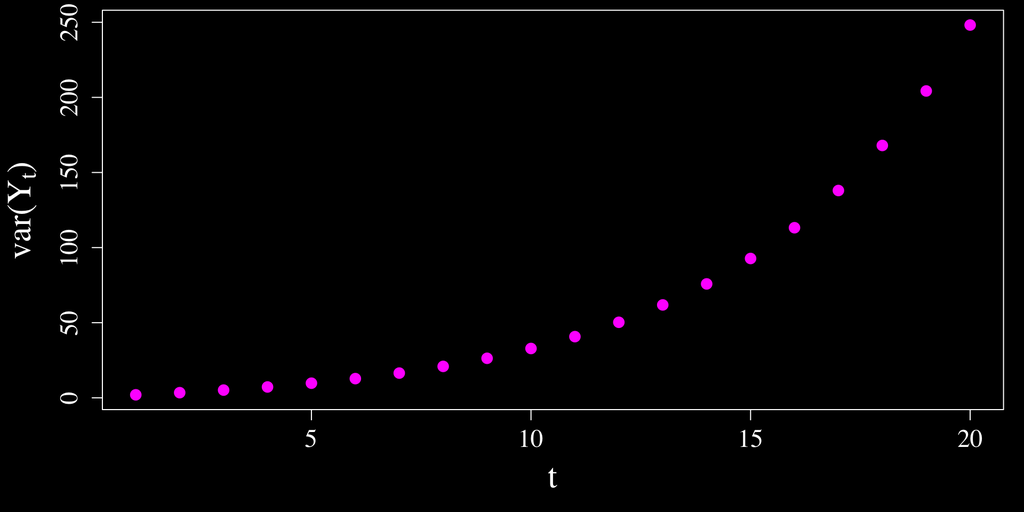

## Some simulated sample paths

$\qquad Y_t = \phi_1 Y_{t-1} + U_t, \quad {\color{orange}{\phi_1=0.0}}$

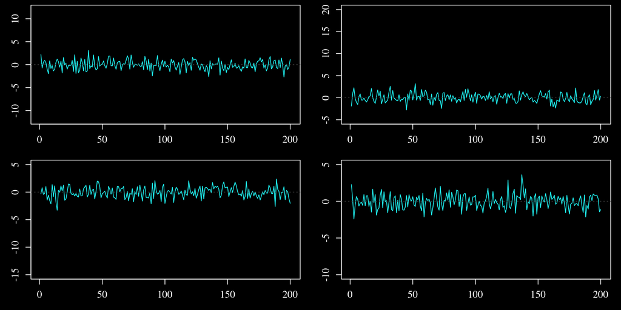

## Some simulated sample paths

$\qquad Y_t = \phi_1 Y_{t-1} + U_t, \quad {\color{orange}{\phi_1=0.2}}$

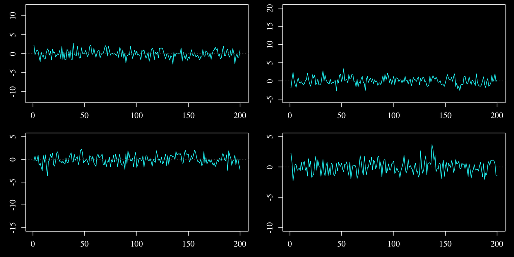

## Some simulated sample paths

$\qquad Y_t = \phi_1 Y_{t-1} + U_t, \quad {\color{orange}{\phi_1=0.4}}$

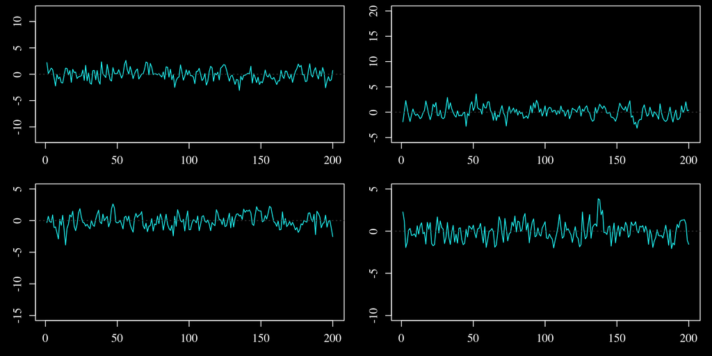

## Some simulated sample paths

$\qquad Y_t = \phi_1 Y_{t-1} + U_t, \quad {\color{orange}{\phi_1=0.6}}$

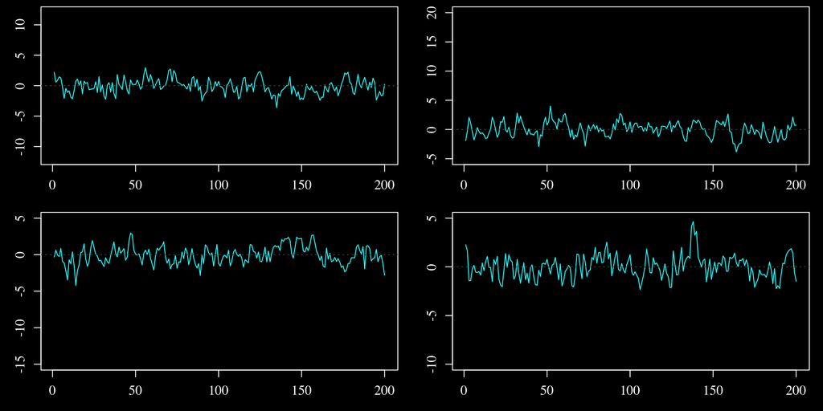

## Some simulated sample paths

$\qquad Y_t = \phi_1 Y_{t-1} + U_t, \quad {\color{orange}{\phi_1=0.8}}$

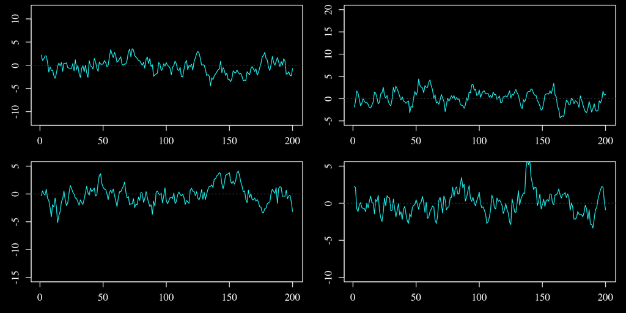

## Some simulated sample paths

$\qquad Y_t = \phi_1 Y_{t-1} + U_t, \quad {\color{orange}{\phi_1=0.9}}$

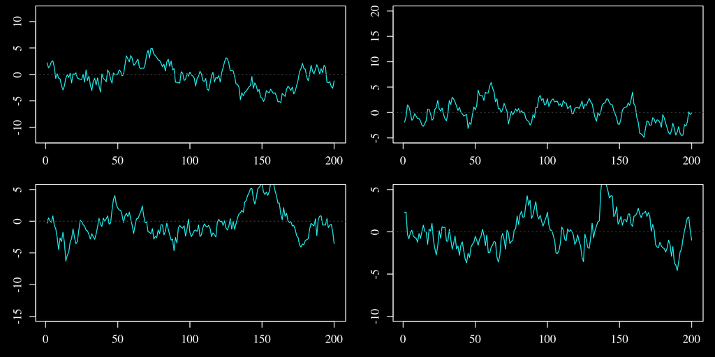

## Some simulated sample paths

$\qquad Y_t = \phi_1 Y_{t-1} + U_t, \quad {\color{orange}{\phi_1=0.95}}$

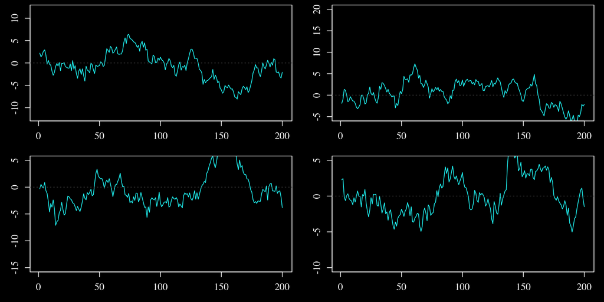

## Some simulated sample paths

$\qquad Y_t = \phi_1 Y_{t-1} + U_t, \quad {\color{orange}{\phi_1=0.99}}$

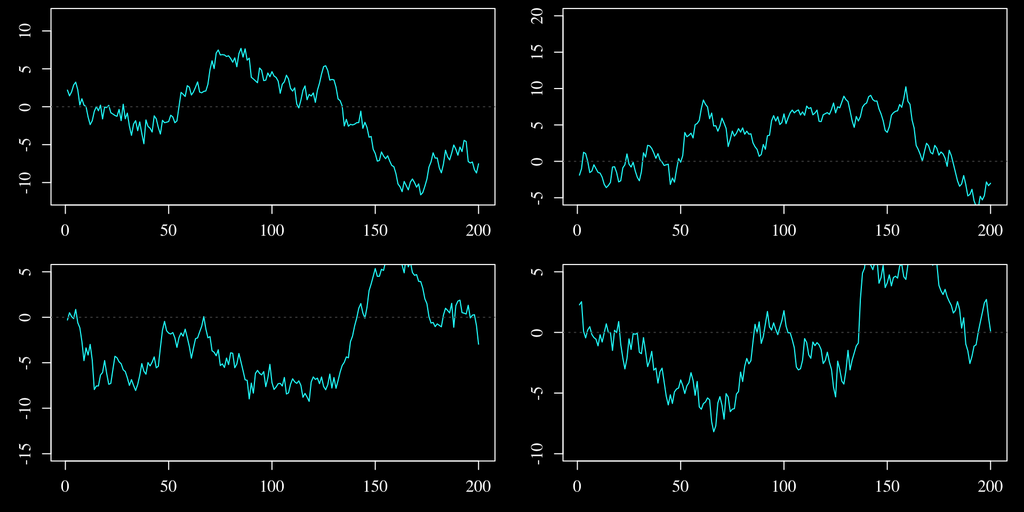

## Some simulated sample paths

$\qquad Y_t = \phi_1 Y_{t-1} + U_t, \quad {\color{orange}{\phi_1=1.0}}$

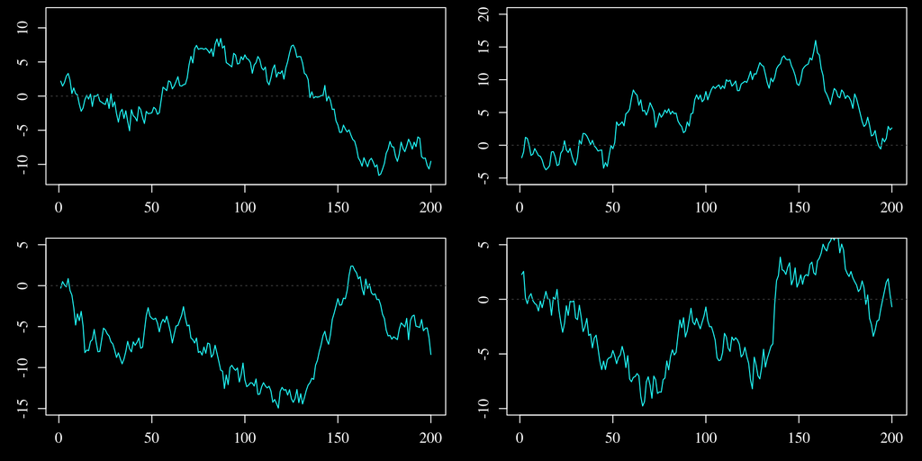

## Some simulated sample paths

$\qquad Y_t = \phi_1 Y_{t-1} + U_t, \quad {\color{orange}{\phi_1=1.03}}$

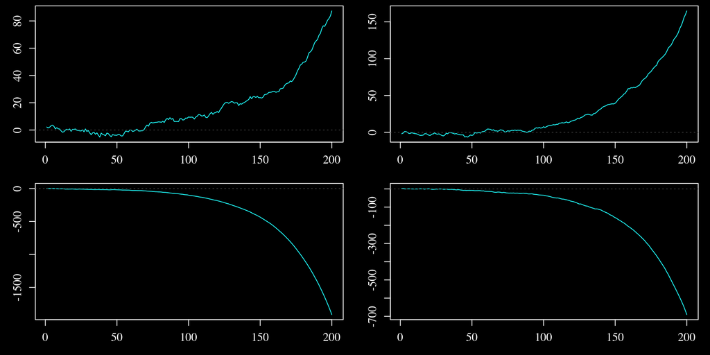

$${\large{\textbf{Differencing for Stationarity}}}$$

## Differencing for stationarity

The random walk is non-stationary:
$$Y_t = Y_{t-1} + U_t$$
The *first difference* is stationary:
$$\Delta Y_t = Y_t-Y_{t-1} = U_t$$

Differencing an explosive AR(1) does *not* produce stationarity. (Rare in practice.)

## Differencing for stationarity

It is conventional to

- specify a deterministic regression
- apply differencing

to produce a stationary time series.

## Differencing for stationarity

It is conventional to

- specify a deterministic regression
- apply differencing ${\color{lime}{d}}$ times

to produce a stationary time series. Then

- specify an ARIMA$(p,{\color{lime}{d}},q)$ model.

## Testing for differencing in an AR(1) model

$$\begin{align}
Y_t &= X_t'\beta + Z_t \\
Z_t &= \phi_1 Z_{t-1} + U_t
\end{align}$$

## Testing for differencing in an AR(1) model

$$\begin{align}
Y_t &= X_t'\beta + Z_t \\
Z_t &= {\color{magenta}{\phi_1}} Z_{t-1} + U_t
\end{align}$$

${\color{magenta}{\phi_1=1}}$ : “unit root”, differencing required.

${\color{magenta}{\phi_1<1}}$ : stationary, no differencing required.

## Testing for differencing in an AR(1) model

$$\begin{align}
Y_t &= X_t'\beta + Z_t \\
Z_t &= {\color{magenta}{\phi_1}} Z_{t-1} + U_t
\end{align}$$

${\color{cyan}{H_0}} : {\color{magenta}{\phi_1=1}}$ : “unit root”, differencing required.

${\color{cyan}{H_1}} : {\color{magenta}{\phi_1<1}}$ : stationary, no differencing required.

“Dickey-Fuller” test:  
$\quad t_{\text{DF}} = \dfrac{\widehat\phi_1-1}{\text{s.e.}(\widehat\phi_1)}$ (nonstandard critical/$p$-value)

## The Augmented Dickey-Fuller test

AR(1):
$$Z_t = \phi_1 Z_{t-1} + U_t$$
can be written
$$\begin{align}
{\color{white}{Z_t}}\ {\color{magenta}{- \ Z_{t-1}}}
= {\color{white}{(\phi_1}}{\color{magenta}{\, -\, 1}}{\color{white}{)}}
\, Z_{t-1} + U_t
\end{align}$$

## The Augmented Dickey-Fuller test

AR(1):
$$Z_t = \phi_1 Z_{t-1} + U_t$$
can be written
$$\begin{align}
{\color{magenta}{Z_t}}\ {\color{magenta}{- \ Z_{t-1}}}
&= {\color{cyan}{(\phi_1}}{\color{cyan}{\, -\, 1}}{\color{cyan}{)}}
\, Z_{t-1} + U_t \\
{\color{magenta}{\Delta Z_t}} &=
\quad\:\:{\color{cyan}{\varphi}}\quad\: Z_{t-1} + U_t
\end{align}$$

$$\begin{array}{l}
H_0 : {\color{cyan}{\phi_1=1}} \\
H_1 : {\color{cyan}{\phi_1<1}}
\end{array}
\quad \Rightarrow \quad
\begin{array}{l}
H_0 : {\color{cyan}{\varphi=0}} \\
H_1 : {\color{cyan}{\varphi<0}}
\end{array}$$

## The Augmented Dickey-Fuller test

AR(2):
$$Z_t = \phi_1 Z_{t-1} + \phi_2 Z_{t-2} + U_t$$
can be written
$$\begin{align}
{\color{white}{Z_t}}\,{\color{magenta}{-Z_{t-1}}} &=
{\color{white}{(\phi_1}}{\color{lime}{\,+\,\phi_2}}
{\color{magenta}{\,-\,1}}{\color{white}{)}}
Z_{t-1}
{\color{lime}{\,-\, \phi_2}} (Z_{t-1}-Z_{t-2}) + U_t
\end{align}$$

## The Augmented Dickey-Fuller test

AR(2):
$$Z_t = \phi_1 Z_{t-1} + \phi_2 Z_{t-2} + U_t$$
can be written
$$\begin{align}
{\color{magenta}{Z_t}}\,{\color{magenta}{-Z_{t-1}}} &=
{\color{cyan}{(\phi_1}}{\color{cyan}{\,+\,\phi_2}}
{\color{cyan}{\,-\,1}}{\color{cyan}{)}}
Z_{t-1}
{\color{lime}{\,-\, \phi_2}} {\color{orange}{(Z_{t-1}-Z_{t-2})}} + U_t \\
{\color{magenta}{\Delta Z_t}} &=
\qquad{\color{cyan}{\varphi}}\qquad\quad Z_{t-1} \,
{\color{lime}{+\: \psi_1}}\quad {\color{orange}{\Delta Z_{t-1}}}
\quad\:\: + U_t
\end{align}$$

## The Augmented Dickey-Fuller test

AR(2):
$$Z_t = \phi_1 Z_{t-1} + \phi_2 Z_{t-2} + U_t$$
can be written
$$\Delta Z_t = \varphi Z_{t-1}
+ \psi_1 \Delta Z_{t-1} + U_t$$

## The Augmented Dickey-Fuller test

AR(2):
$$Z_t = \phi_1 Z_{t-1} + \phi_2 Z_{t-2} + U_t$$
can be written
$${\color{cyan}{\Delta Z_t}} =
{\phantom{\varphi Z_{t-1}}}\phantom{+} \:\:
\psi_1 {\color{cyan}{\Delta Z_{t-1}}} + U_t$$

$$\varphi=0 \quad \Rightarrow \quad \text{AR(1) model for }
{\color{cyan}{\Delta Z_t}}$$

## The Augmented Dickey-Fuller test

AR(2):
$$Z_t = \phi_1 Z_{t-1} + \phi_2 Z_{t-2} + U_t$$
can be written
$${\color{cyan}{\Delta Z_t}} =
{\phantom{\varphi Z_{t-1}}}\phantom{+} \:\:
\psi_1 {\color{cyan}{\Delta Z_{t-1}}} + U_t$$

$$\varphi=0 \quad \Rightarrow \quad \text{AR(1) model for }
{\color{cyan}{\Delta Z_t}}$$

## The Augmented Dickey-Fuller test

AR(2):
$$Z_t = \phi_1 Z_{t-1} + \phi_2 Z_{t-2} + U_t$$
can be written
$${\color{magenta}{\Delta}}{\color{cyan}{Z_t}} =
{\phantom{\varphi Z_{t-1}}}\phantom{+} \:\:
\psi_1
{\color{magenta}{\Delta}}{\color{cyan}{Z_{t-{\color{orange}{1}}}}}
+ U_t$$

$$\varphi=0 \quad \Rightarrow \quad \text{AR(1) model for }
{\color{cyan}{\Delta Z_t}}$$

$$\phantom{\varphi=0} \qquad\quad\:\:\: \Rightarrow \quad
\text{ARIMA}({\color{orange}{1}}, {\color{magenta}{1}},0)
\text{ model for } {\color{cyan}{Z_t}}$$

## The Augmented Dickey-Fuller test

AR($p$):
$$Z_t = \phi_1 Z_{t-1} + \phi_2 Z_{t-2} +\ldots +
\phi_p Z_{t-p} + U_t$$
can be written
$$\Delta Z_t = \varphi Z_{t-1} + \psi_1 \Delta Z_{t-1} + \ldots
+ \psi_{p-1} \Delta Z_{t-p+1} + U_t$$

## The Augmented Dickey-Fuller test

AR($p$):
$$Z_t = \phi_1 Z_{t-1} + \phi_2 Z_{t-2} +\ldots +
\phi_p Z_{t-p} + U_t$$
can be written
$$\Delta Z_t = \phantom{\varphi Z_{t-1} +} \:\:
\psi_1 \Delta Z_{t-1} + \ldots
+ \psi_{p-1} \Delta Z_{t-p+1} + U_t$$

$$\begin{align}
\varphi=0 \quad &\Rightarrow \quad \text{AR}(p-1) \text{ model for } \Delta Z_t \\
& \Rightarrow \quad \text{ARIMA}(p-1,1,0) \text{ model for } Z_t
\end{align}$$

## The Augmented Dickey-Fuller test

$$\begin{align}
Y_t &= X_t'\beta + Z_t \\
\Delta Z_t &= \varphi Z_{t-1} +
\psi_1 \Delta Z_{t-1} + \ldots
+ \psi_{p-1} \Delta Z_{t-p+1} + U_t
\end{align}$$

1. Choose $X_t$ based on time series plot.
2. Choose $p$ by AIC (approximate model)
3. ADF test:  
   $H_0 : \varphi=0 \quad \text{unit root, difference } Z_t$  
   $H_1 : \varphi<0 \quad Z_t \text{ stationary, no difference}$